# AnalisisSentimenTerkaitKuliahOnlinepadaTwitterdenganMenggunakanMetodeNaiveBayes

```python
from google.colab import files
uploaded = files.upload()
```

Upload widget is only available when the cell has been executed in the current browser session. Please rerun this cell to enable.

```
Saving Data Kuliah online.csv to Data Kuliah online (2).csv
```

```python
import pandas as pd
import numpy as np
import matplotlib.pyplot as plt
from sklearn.feature_extraction.text import CountVectorizer
import nltk
import string
import re
nltk.download('stopwords')
```

```
True
```

```python
df = pd.read_csv('Data Kuliah online (2).csv',encoding ="unicode_escape")
```

```python
df.head(10)
```

|  | Timestamp | Username | tweet |
| --- | --- | --- | --- |
| 0 | 6/1/2021 4:52 | Newbie102000 | @undipmenfess Hmm... nongki tetep jalan tapi k... |
| 1 | 6/1/2021 4:45 | tsarb1tch | @undipmenfess yee baru 2020 jg perjalanan lo d... |
| 2 | 6/1/2021 4:45 | langterkataken | Bayangin lo belajar di kampus sem 1 doang sem ... |
| 3 | 6/1/2021 4:44 | tokiovillain | Emang paling bener kuliah online sampe semester 4 |
| 4 | 6/1/2021 4:40 | erhaemef | Kalau kuliah masih online, ke Pontianak sepi s... |
| 5 | 6/1/2021 4:39 | araafi_aprilia | @collegemenfess dulu smt.4 banyakan nangis kar... |
| 6 | 6/1/2021 4:38 | gulfedmew | wkwkwk papaku kaget kuliah online tetep diabse... |
| 7 | 6/1/2021 4:36 | sweetestguurl | aduh babi udah gamau bgt kuliah onlineð© |
| 8 | 6/1/2021 4:29 | daffafauzankali | kuliah online mah cuma akal akalan bapaklu aja |
| 9 | 6/1/2021 4:23 | ekspetasivisual | RT @akunyakul: apa yang kalian dapet dari kuli... |

```python
#menghapus kolom yang tidak digunakkan
del df['Timestamp']
del df['Username']
```

```python
#data setelah beberapa kolom dihapus
df.head(5)
```

|  | tweet |
| --- | --- |
| 0 | @undipmenfess Hmm... nongki tetep jalan tapi k... |
| 1 | @undipmenfess yee baru 2020 jg perjalanan lo d... |
| 2 | Bayangin lo belajar di kampus sem 1 doang sem ... |
| 3 | Emang paling bener kuliah online sampe semester 4 |
| 4 | Kalau kuliah masih online, ke Pontianak sepi s... |

```python
#menghapus data yang null
df = df.dropna(subset=["tweet"], axis=0) #menghapus data yang null dari kolom tweet
df
```

|  | tweet |
| --- | --- |
| 0 | @undipmenfess Hmm... nongki tetep jalan tapi k... |
| 1 | @undipmenfess yee baru 2020 jg perjalanan lo d... |
| 2 | Bayangin lo belajar di kampus sem 1 doang sem ... |
| 3 | Emang paling bener kuliah online sampe semester 4 |
| 4 | Kalau kuliah masih online, ke Pontianak sepi s... |
| ... | ... |
| 595 | [Cm] guys maaf mau tanya tapi no offense pihak... |
| 596 | Inilah alasan kenapa saya juga lebih milih kul... |
| 597 | @CHOMlNW00 soalnya kuliah ku offlineðð¤ð... |
| 598 | @collegemenfess udah gainget jadwal matkul kap... |
| 599 | @Sam_Ardi Kang, bikin kuliah online arab pegon... |

600 rows × 1 columns

```python
print('Dataset size:', df.shape)
print('columns are:', df.columns)
```

```
Dataset size: (600, 1)
columns are: Index(['tweet'], dtype='object')
```

```python
df.info()
```

```
<class 'pandas.core.frame.DataFrame'>
Int64Index: 600 entries, 0 to 599
Data columns (total 1 columns):
 #   Column  Non-Null Count  Dtype
---  ------  --------------  -----
 0   tweet   600 non-null    object
dtypes: object(1)
memory usage: 9.4+ KB
```

# *Preprocessing Data*

*Cleaning teks*

```python
#cleaning url

def remove_punct(teks):
  teks = re.sub('((www\.[^\s]+)|(https?://[^\s]+))', ' ', teks)   # Remove URLs
  return teks

df['cleaning_tweets'] = df['tweet'].apply(lambda x: remove_punct(x.lower()) )
df.head(5)
```

|  | tweet | cleaning_tweets |
| --- | --- | --- |
| 0 | @undipmenfess Hmm... nongki tetep jalan tapi k... | @undipmenfess hmm... nongki tetep jalan tapi k... |
| 1 | @undipmenfess yee baru 2020 jg perjalanan lo d... | @undipmenfess yee baru 2020 jg perjalanan lo d... |
| 2 | Bayangin lo belajar di kampus sem 1 doang sem ... | bayangin lo belajar di kampus sem 1 doang sem ... |
| 3 | Emang paling bener kuliah online sampe semester 4 | emang paling bener kuliah online sampe semester 4 |
| 4 | Kalau kuliah masih online, ke Pontianak sepi s... | kalau kuliah masih online, ke pontianak sepi s... |

```python
#cleaning teks dan case folding

def remove_punct(teks):
  teks = re.sub('@[\w]+','',teks)                                 # Removes usernames
  teks = re.sub(r'[^a-zA-Z0-9]',' ', str(teks))                   #remove non alphabet and non number
  teks = re.sub(r'\b\w{1,2}\b',' ',teks)
  teks = re.sub(r"\d+", " ", teks)                                # Removes all digits
  teks = re.sub('&quot;'," ", teks)                               # Remove (&quot;)
  teks = re.sub(r'\s\s+',' ', teks)                               #remove 2 space to 1 space
  return teks

df['cleaning_tweets'] = df['cleaning_tweets'].apply(lambda x: remove_punct(x.lower()) )
df.head(5)
```

|  | tweet | cleaning_tweets |
| --- | --- | --- |
| 0 | @undipmenfess Hmm... nongki tetep jalan tapi k... | hmm nongki tetep jalan tapi kuliah online |
| 1 | @undipmenfess yee baru 2020 jg perjalanan lo d... | yee baru perjalanan kuliah masih lama dan gac... |
| 2 | Bayangin lo belajar di kampus sem 1 doang sem ... | bayangin belajar kampus sem doang sem nyampe s... |
| 3 | Emang paling bener kuliah online sampe semester 4 | emang paling bener kuliah online sampe semester |
| 4 | Kalau kuliah masih online, ke Pontianak sepi s... | kalau kuliah masih online pontianak sepi sekali |

# **Tokenization**

```python
#tokenization

def tokenization(teks):
  teks = re.split('\W+', teks)
  return teks

df['Tokenization'] = df['cleaning_tweets'].apply(lambda x: tokenization(x))
df.head(5)
```

|  | tweet | cleaning_tweets | Tokenization |
| --- | --- | --- | --- |
| 0 | @undipmenfess Hmm... nongki tetep jalan tapi k... | hmm nongki tetep jalan tapi kuliah online | [, hmm, nongki, tetep, jalan, tapi, kuliah, on... |
| 1 | @undipmenfess yee baru 2020 jg perjalanan lo d... | yee baru perjalanan kuliah masih lama dan gac... | [, yee, baru, perjalanan, kuliah, masih, lama,... |
| 2 | Bayangin lo belajar di kampus sem 1 doang sem ... | bayangin belajar kampus sem doang sem nyampe s... | [bayangin, belajar, kampus, sem, doang, sem, n... |
| 3 | Emang paling bener kuliah online sampe semester 4 | emang paling bener kuliah online sampe semester | [emang, paling, bener, kuliah, online, sampe, ... |
| 4 | Kalau kuliah masih online, ke Pontianak sepi s... | kalau kuliah masih online pontianak sepi sekali | [kalau, kuliah, masih, online, pontianak, sepi... |

# **Stop removal**

Menghilangkan stopword (kata yang kurang bermakna).

```python
#stopword removal

stopword = nltk.corpus.stopwords.words('indonesian')

def remove_stopwords(teks):
  teks = [word for word in teks if word not in stopword]
  return teks

df['Stop_removal'] = df['Tokenization'].apply(lambda x: remove_stopwords(x))
df.head(5)
```

|  | tweet | cleaning_tweets | Tokenization | Stop_removal |
| --- | --- | --- | --- | --- |
| 0 | @undipmenfess Hmm... nongki tetep jalan tapi k... | hmm nongki tetep jalan tapi kuliah online | [, hmm, nongki, tetep, jalan, tapi, kuliah, on... | [, hmm, nongki, tetep, jalan, kuliah, online] |
| 1 | @undipmenfess yee baru 2020 jg perjalanan lo d... | yee baru perjalanan kuliah masih lama dan gac... | [, yee, baru, perjalanan, kuliah, masih, lama,... | [, yee, perjalanan, kuliah, gacuma, angakatan,... |
| 2 | Bayangin lo belajar di kampus sem 1 doang sem ... | bayangin belajar kampus sem doang sem nyampe s... | [bayangin, belajar, kampus, sem, doang, sem, n... | [bayangin, belajar, kampus, sem, doang, sem, n... |
| 3 | Emang paling bener kuliah online sampe semester 4 | emang paling bener kuliah online sampe semester | [emang, paling, bener, kuliah, online, sampe, ... | [emang, bener, kuliah, online, sampe, semester, ] |
| 4 | Kalau kuliah masih online, ke Pontianak sepi s... | kalau kuliah masih online pontianak sepi sekali | [kalau, kuliah, masih, online, pontianak, sepi... | [kuliah, online, pontianak, sepi, ] |

```python
#menggabungkan kata di stop removal
def fit_stopwords(teks):
  teks = np.array(teks)
  teks = ' '.join(teks)

  return teks

df['Stop_removal'] = df['Stop_removal'].apply(lambda x: fit_stopwords(x))
df.head(5)
```

|  | tweet | cleaning_tweets | Tokenization | Stop_removal |
| --- | --- | --- | --- | --- |
| 0 | @undipmenfess Hmm... nongki tetep jalan tapi k... | hmm nongki tetep jalan tapi kuliah online | [, hmm, nongki, tetep, jalan, tapi, kuliah, on... | hmm nongki tetep jalan kuliah online |
| 1 | @undipmenfess yee baru 2020 jg perjalanan lo d... | yee baru perjalanan kuliah masih lama dan gac... | [, yee, baru, perjalanan, kuliah, masih, lama,... | yee perjalanan kuliah gacuma angakatan aja on... |
| 2 | Bayangin lo belajar di kampus sem 1 doang sem ... | bayangin belajar kampus sem doang sem nyampe s... | [bayangin, belajar, kampus, sem, doang, sem, n... | bayangin belajar kampus sem doang sem nyampe s... |
| 3 | Emang paling bener kuliah online sampe semester 4 | emang paling bener kuliah online sampe semester | [emang, paling, bener, kuliah, online, sampe, ... | emang bener kuliah online sampe semester |
| 4 | Kalau kuliah masih online, ke Pontianak sepi s... | kalau kuliah masih online pontianak sepi sekali | [kalau, kuliah, masih, online, pontianak, sepi... | kuliah online pontianak sepi |

```python
df['tweet_preprocessing'] = df['Stop_removal']
df.head(5)
```

|  | tweet | cleaning_tweets | Tokenization | Stop_removal | tweet_preprocessing |
| --- | --- | --- | --- | --- | --- |
| 0 | @undipmenfess Hmm... nongki tetep jalan tapi k... | hmm nongki tetep jalan tapi kuliah online | [, hmm, nongki, tetep, jalan, tapi, kuliah, on... | hmm nongki tetep jalan kuliah online | hmm nongki tetep jalan kuliah online |
| 1 | @undipmenfess yee baru 2020 jg perjalanan lo d... | yee baru perjalanan kuliah masih lama dan gac... | [, yee, baru, perjalanan, kuliah, masih, lama,... | yee perjalanan kuliah gacuma angakatan aja on... | yee perjalanan kuliah gacuma angakatan aja on... |
| 2 | Bayangin lo belajar di kampus sem 1 doang sem ... | bayangin belajar kampus sem doang sem nyampe s... | [bayangin, belajar, kampus, sem, doang, sem, n... | bayangin belajar kampus sem doang sem nyampe s... | bayangin belajar kampus sem doang sem nyampe s... |
| 3 | Emang paling bener kuliah online sampe semester 4 | emang paling bener kuliah online sampe semester | [emang, paling, bener, kuliah, online, sampe, ... | emang bener kuliah online sampe semester | emang bener kuliah online sampe semester |
| 4 | Kalau kuliah masih online, ke Pontianak sepi s... | kalau kuliah masih online pontianak sepi sekali | [kalau, kuliah, masih, online, pontianak, sepi... | kuliah online pontianak sepi | kuliah online pontianak sepi |

**Menghapus duplikat data**

```python
# dropping ALL duplicate values
df.drop_duplicates(subset ="tweet_preprocessing",
                     keep = False, inplace = True)

# displaying data
df
```

|  | tweet | cleaning_tweets | Tokenization | Stop_removal | tweet_preprocessing |
| --- | --- | --- | --- | --- | --- |
| 0 | @undipmenfess Hmm... nongki tetep jalan tapi k... | hmm nongki tetep jalan tapi kuliah online | [, hmm, nongki, tetep, jalan, tapi, kuliah, on... | hmm nongki tetep jalan kuliah online | hmm nongki tetep jalan kuliah online |
| 1 | @undipmenfess yee baru 2020 jg perjalanan lo d... | yee baru perjalanan kuliah masih lama dan gac... | [, yee, baru, perjalanan, kuliah, masih, lama,... | yee perjalanan kuliah gacuma angakatan aja on... | yee perjalanan kuliah gacuma angakatan aja on... |
| 2 | Bayangin lo belajar di kampus sem 1 doang sem ... | bayangin belajar kampus sem doang sem nyampe s... | [bayangin, belajar, kampus, sem, doang, sem, n... | bayangin belajar kampus sem doang sem nyampe s... | bayangin belajar kampus sem doang sem nyampe s... |
| 3 | Emang paling bener kuliah online sampe semester 4 | emang paling bener kuliah online sampe semester | [emang, paling, bener, kuliah, online, sampe, ... | emang bener kuliah online sampe semester | emang bener kuliah online sampe semester |
| 4 | Kalau kuliah masih online, ke Pontianak sepi s... | kalau kuliah masih online pontianak sepi sekali | [kalau, kuliah, masih, online, pontianak, sepi... | kuliah online pontianak sepi | kuliah online pontianak sepi |
| ... | ... | ... | ... | ... | ... |
| 595 | [Cm] guys maaf mau tanya tapi no offense pihak... | guys maaf mau tanya tapi offense pihak manapu... | [, guys, maaf, mau, tanya, tapi, offense, piha... | guys maaf offense manapun dosen kadang memaks... | guys maaf offense manapun dosen kadang memaks... |
| 596 | Inilah alasan kenapa saya juga lebih milih kul... | inilah alasan kenapa saya juga lebih milih kul... | [inilah, alasan, kenapa, saya, juga, lebih, mi... | alasan milih kuliah online | alasan milih kuliah online |
| 597 | @CHOMlNW00 soalnya kuliah ku offlineðð¤ð... | soalnya kuliah offline mana kelas pagi muluuu... | [, soalnya, kuliah, offline, mana, kelas, pagi... | kuliah offline kelas pagi muluuuuuu online te... | kuliah offline kelas pagi muluuuuuu online te... |
| 598 | @collegemenfess udah gainget jadwal matkul kap... | udah gainget jadwal matkul kapan aja karna do... | [, udah, gainget, jadwal, matkul, kapan, aja, ... | udah gainget jadwal matkul aja karna dosen do... | udah gainget jadwal matkul aja karna dosen do... |
| 599 | @Sam_Ardi Kang, bikin kuliah online arab pegon... | kang bikin kuliah online arab pegon lagi dong... | [, kang, bikin, kuliah, online, arab, pegon, l... | kang bikin kuliah online arab pegon biar namb... | kang bikin kuliah online arab pegon biar namb... |

352 rows × 5 columns

```python
df.shape
```

```
(352, 5)
```

```python
df.to_csv("tweetsPreprocessing.csv")
from google.colab import files
files.download('tweetsPreprocessing.csv')
```

# **NAIVE BAYES**

```python
from google.colab import files
uploaded = files.upload()
```

Upload widget is only available when the cell has been executed in the current browser session. Please rerun this cell to enable.

```
Saving tweetsPreprocessing - with labeling.csv to tweetsPreprocessing - with labeling (2).csv
```

```python
df = pd.read_csv('tweetsPreprocessing - with labeling (2).csv')
df
```

|  | tweet | cleaning_tweets | Tokenization | Stop_removal | tweet_preprocessing | label |
| --- | --- | --- | --- | --- | --- | --- |
| 0 | @undipmenfess Hmm... nongki tetep jalan tapi k... | hmm nongki tetep jalan tapi kuliah online | ['', 'hmm', 'nongki', 'tetep', 'jalan', 'tapi'... | hmm nongki tetep jalan kuliah online | hmm nongki tetep jalan kuliah online | positif |
| 1 | @undipmenfess yee baru 2020 jg perjalanan lo d... | yee baru perjalanan kuliah masih lama dan gacu... | ['', 'yee', 'baru', 'perjalanan', 'kuliah', 'm... | yee perjalanan kuliah gacuma angakatan aja onl... | yee perjalanan kuliah gacuma angakatan aja onl... | negatif |
| 2 | Bayangin lo belajar di kampus sem 1 doang sem ... | bayangin belajar kampus sem doang sem nyampe s... | ['bayangin', 'belajar', 'kampus', 'sem', 'doan... | bayangin belajar kampus sem doang sem nyampe s... | bayangin belajar kampus sem doang sem nyampe s... | positif |
| 3 | Emang paling bener kuliah online sampe semester 4 | emang paling bener kuliah online sampe semester | ['emang', 'paling', 'bener', 'kuliah', 'online... | emang bener kuliah online sampe semester | emang bener kuliah online sampe semester | positif |
| 4 | Kalau kuliah masih online, ke Pontianak sepi s... | kalau kuliah masih online pontianak sepi sekali | ['kalau', 'kuliah', 'masih', 'online', 'pontia... | kuliah online pontianak sepi | kuliah online pontianak sepi | positif |
| ... | ... | ... | ... | ... | ... | ... |
| 347 | [Cm] guys maaf mau tanya tapi no offense pihak... | guys maaf mau tanya tapi offense pihak manapun... | ['', 'guys', 'maaf', 'mau', 'tanya', 'tapi', '... | guys maaf offense manapun dosen kadang memaksa... | guys maaf offense manapun dosen kadang memaksa... | negatif |
| 348 | Inilah alasan kenapa saya juga lebih milih kul... | inilah alasan kenapa saya juga lebih milih kul... | ['inilah', 'alasan', 'kenapa', 'saya', 'juga',... | alasan milih kuliah online | alasan milih kuliah online | netral |
| 349 | @CHOMlNW00 soalnya kuliah ku offlineðð¤ð... | soalnya kuliah offline mana kelas pagi muluuuu... | ['', 'soalnya', 'kuliah', 'offline', 'mana', '... | kuliah offline kelas pagi muluuuuuu online tet... | kuliah offline kelas pagi muluuuuuu online tet... | negatif |
| 350 | @collegemenfess udah gainget jadwal matkul kap... | udah gainget jadwal matkul kapan aja karna dos... | ['', 'udah', 'gainget', 'jadwal', 'matkul', 'k... | udah gainget jadwal matkul aja karna dosen dos... | udah gainget jadwal matkul aja karna dosen dos... | negatif |
| 351 | @Sam_Ardi Kang, bikin kuliah online arab pegon... | kang bikin kuliah online arab pegon lagi dong ... | ['', 'kang', 'bikin', 'kuliah', 'online', 'ara... | kang bikin kuliah online arab pegon biar namba... | kang bikin kuliah online arab pegon biar namba... | positif |

352 rows × 6 columns

```python
print('Dataset size:', df.shape)
print('columns are:', df.columns)
```

```
Dataset size: (352, 6)
columns are: Index(['tweet', 'cleaning_tweets', 'Tokenization', 'Stop_removal',
       'tweet_preprocessing', 'label'],
      dtype='object')
```

```python
import json
import matplotlib.pyplot as plt
from wordcloud import WordCloud
import seaborn as sns
```

```python
#menghapus data dengan sentimen netral
df = df.drop(df[df.label == "netral"].index)
print('Dataset size:', df.shape)
print('columns are:', df.columns)
```

```
Dataset size: (207, 6)
columns are: Index(['tweet', 'cleaning_tweets', 'Tokenization', 'Stop_removal',
       'tweet_preprocessing', 'label'],
      dtype='object')
```

```python
#mencari nilai polaritas data dari label
def convert(label):
  if label == 'positif':
    return 1
  else:
    return 0
```

```python
df['Sentimen'] = df['label'].apply(convert)
df.head(5)
```

|  | tweet | cleaning_tweets | Tokenization | Stop_removal | tweet_preprocessing | label | Sentimen |
| --- | --- | --- | --- | --- | --- | --- | --- |
| 0 | @undipmenfess Hmm... nongki tetep jalan tapi k... | hmm nongki tetep jalan tapi kuliah online | ['', 'hmm', 'nongki', 'tetep', 'jalan', 'tapi'... | hmm nongki tetep jalan kuliah online | hmm nongki tetep jalan kuliah online | positif | 1 |
| 1 | @undipmenfess yee baru 2020 jg perjalanan lo d... | yee baru perjalanan kuliah masih lama dan gacu... | ['', 'yee', 'baru', 'perjalanan', 'kuliah', 'm... | yee perjalanan kuliah gacuma angakatan aja onl... | yee perjalanan kuliah gacuma angakatan aja onl... | negatif | 0 |
| 2 | Bayangin lo belajar di kampus sem 1 doang sem ... | bayangin belajar kampus sem doang sem nyampe s... | ['bayangin', 'belajar', 'kampus', 'sem', 'doan... | bayangin belajar kampus sem doang sem nyampe s... | bayangin belajar kampus sem doang sem nyampe s... | positif | 1 |
| 3 | Emang paling bener kuliah online sampe semester 4 | emang paling bener kuliah online sampe semester | ['emang', 'paling', 'bener', 'kuliah', 'online... | emang bener kuliah online sampe semester | emang bener kuliah online sampe semester | positif | 1 |
| 4 | Kalau kuliah masih online, ke Pontianak sepi s... | kalau kuliah masih online pontianak sepi sekali | ['kalau', 'kuliah', 'masih', 'online', 'pontia... | kuliah online pontianak sepi | kuliah online pontianak sepi | positif | 1 |

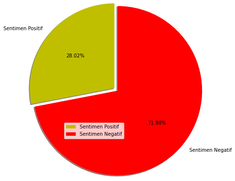

```python
sentiment_tweet = ['Sentimen Positif', 'Sentimen Negatif']
slices = [(df['Sentimen'] != 0).sum(), (df['Sentimen'] == 0).sum()]
colors = ['y', 'r']

explode = (0, 0.1)
# # Plot
plt.pie(slices, explode=explode, labels=sentiment_tweet, colors=colors, autopct='%1.2f%%',radius=2,shadow=True, startangle=90)
plt.legend()
plt.show()
```

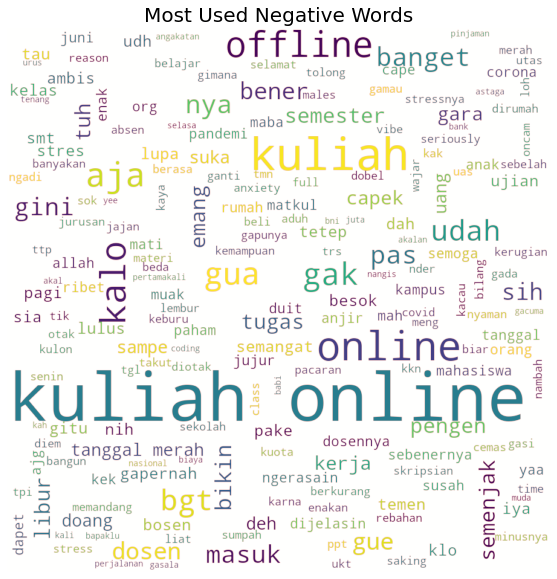

```python
#kata negatif yang banyak digunakkan
title_font = {'size':'20' }
negative_words =' '.join([text for text in df['tweet_preprocessing'][df['Sentimen'] == 0]])
wordcloud = WordCloud(width=900, height=900, random_state=21,max_font_size=110,background_color="RGBA( 233, 140, 122, 1 )", mode="RGBA").generate(negative_words)
plt.figure(dpi=500)
plt.figure(figsize=(10, 10))
plt.imshow(wordcloud, interpolation="bilinear")
plt.axis('off')
plt.title("Most Used Negative Words", **title_font)
plt.show()
```

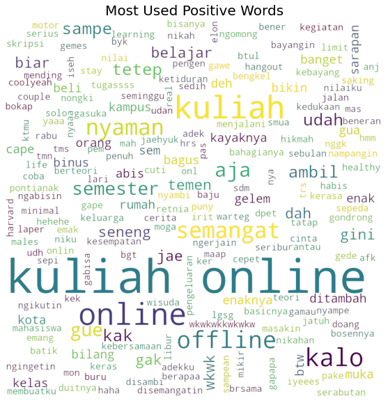

```python
#kata positif yang banyak digunakkan
title_font = {'size':'20'}
positive_words =' '.join([str(text) for text in df['tweet_preprocessing'][df['Sentimen'] == 1]])
wordcloud = WordCloud(width=900, height=900, random_state=21,max_font_size=110,background_color="RGBA(  222, 184, 135, 1  )", mode="RGBA").generate(positive_words)
plt.figure(dpi=500)
plt.figure(figsize=(10, 10))
plt.imshow(wordcloud, interpolation="bilinear")
plt.axis('off')
plt.title("Most Used Positive Words", **title_font)
plt.show()
```

# **Count Vectorizer**

CountVectorizer adalah sebuah metode mengubah data teks dengan menghitung banyaknya kemunculan sebuah kata dalam dokumen teks dan kemudian dari nilai hasil kemunculan tiap kata tersebut diubah menjadi bentuk vektor

```python
X = df['tweet_preprocessing']
```

```python
from sklearn.feature_extraction.text import CountVectorizer
count_vectorizer = CountVectorizer(ngram_range=(1,2))    # Unigram and Bigram
final_vectorized_data = count_vectorizer.fit_transform(X.values.astype(str))
print(final_vectorized_data.toarray())
print("Shape of matrix " , final_vectorized_data.shape)
```

```
[[0 0 0 ... 0 0 0]
 [0 0 0 ... 0 0 0]
 [0 0 0 ... 0 0 0]
 ...
 [0 0 0 ... 0 0 0]
 [0 0 0 ... 0 0 0]
 [0 0 0 ... 0 0 0]]
Shape of matrix  (207, 2309)
```

# **TF-IDF**

TF-IDF adalah sebuah metode mengubah data teks dengan memberikan bobot/nilai terhadap kata berdasarkan seberapa penting kata tersebut dianggap memberikan makna pada kalimat.

```python
from sklearn.feature_extraction.text import TfidfVectorizer

tf_idf_vectorizer = TfidfVectorizer(use_idf=True,ngram_range=(1,3))
tf_final_vectorized_data = tf_idf_vectorizer.fit_transform(X.values.astype(str))
tf_final_vectorized_data.shape
```

```
(207, 3770)
```

# **Splitting Data**

splitting data untuk tes akurasi

```python
from sklearn.model_selection import train_test_split
#Using Countvectorizer
X_train, X_test, y_train, y_test = train_test_split(final_vectorized_data, df['Sentimen'],test_size=0.2, random_state=69)

#using TF-IDF
X_train_tf, X_test_tf, y_train_tf, y_test_tf = train_test_split(tf_final_vectorized_data, df['Sentimen'],test_size=0.2, random_state=69)
```

```python
#Printing splitted dataset sizes

#count vectorizer
print("count vectorizer")
print("X_train_shape : ",X_train.shape)
print("X_test_shape : ",X_test.shape)
print("y_train_shape : ",y_train.shape)
print("y_test_shape : ",y_test.shape)

#Tf-IDF
print("\nTF-IDF")
print("X_train_tf_shape : ",X_train_tf.shape)
print("X_test_tf_shape : ",X_test_tf.shape)
print("y_train_tf_shape : ",y_train_tf.shape)
print("y_test_tf_shape : ",y_test_tf.shape)
```

```
count vectorizer
X_train_shape :  (165, 2309)
X_test_shape :  (42, 2309)
y_train_shape :  (165,)
y_test_shape :  (42,)

TF-IDF
X_train_tf_shape :  (165, 3770)
X_test_tf_shape :  (42, 3770)
y_train_tf_shape :  (165,)
y_test_tf_shape :  (42,)
```

# **Train and predict**

**Multinomial Naive Bayes classifier**

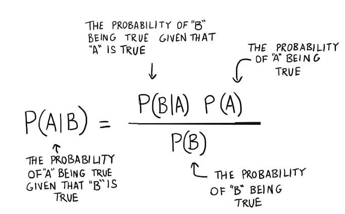

```python
from sklearn.naive_bayes import MultinomialNB  # Naive Bayes Classifier

#count vectorizer
model_naive = MultinomialNB().fit(X_train, y_train)
predicted_naive = model_naive.predict(X_test)

#tf_idf
model_naive_tf = MultinomialNB().fit(X_train_tf, y_train_tf)
predicted_naive_tf = model_naive_tf.predict(X_test_tf)
```

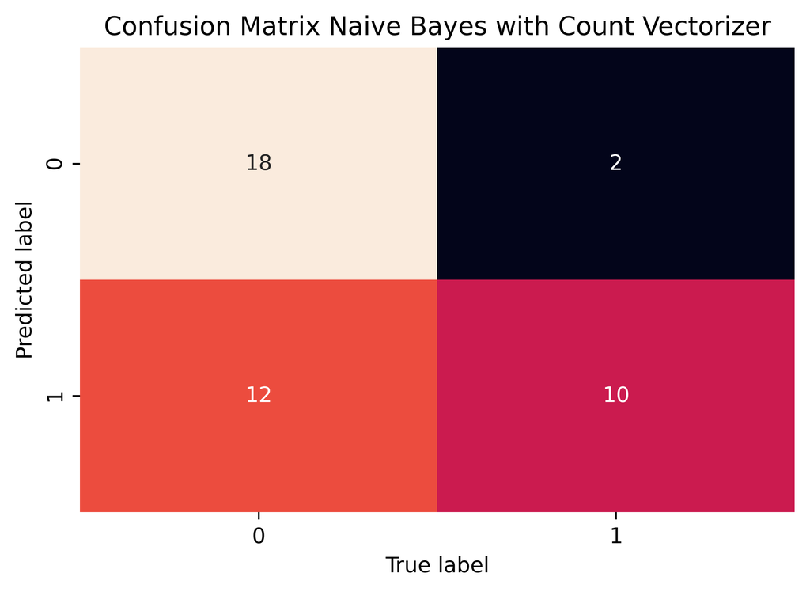

```python
#Count Vectorizer
from sklearn.metrics import confusion_matrix
plt.figure(dpi=500)
mat = confusion_matrix(y_test, predicted_naive)
sns.heatmap(mat.T, annot=True, fmt="d", cbar=False)

plt.title('Confusion Matrix Naive Bayes with Count Vectorizer')
plt.xlabel('True label')
plt.ylabel('Predicted label')
plt.show()
```

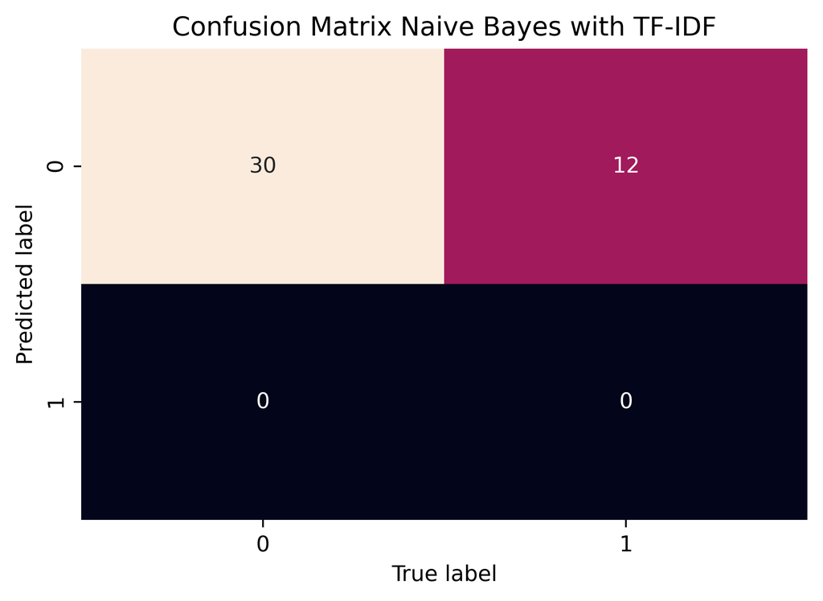

```python
#TF-IDF
plt.figure(dpi=500)
mat = confusion_matrix(y_test_tf, predicted_naive_tf)
sns.heatmap(mat.T, annot=True, fmt="d", cbar=False)

plt.title('Confusion Matrix Naive Bayes with TF-IDF')
plt.xlabel('True label')
plt.ylabel('Predicted label')
plt.show()
```

# **Precision, Recall, and Accuracy**

Precision mengukur berapa banyak teks yang diprediksi dengan benar sebagai suatu kategori dari semua teks yang diprediksi (benar dan salah).

Recall mengukur berapa banyak teks yang diprediksi dengan benar pada kategori tertentu dari semua teks. Hal ini berbanding lurus dengan banyak data semakin banyak data semakin baik.

Accuracy mengukur berapa banyak teks yang diprediksi secara tepat sesuai aktualnya dari semua teks .

```python
from sklearn.metrics import classification_report
print("Count Vectorizer")
print(classification_report(y_test, predicted_naive))

print("\nTF-IDF")
print(classification_report(y_test_tf, predicted_naive_tf))
```

```
Count Vectorizer
              precision    recall  f1-score   support

           0       0.90      0.60      0.72        30
           1       0.45      0.83      0.59        12

    accuracy                           0.67        42
   macro avg       0.68      0.72      0.65        42
weighted avg       0.77      0.67      0.68        42


TF-IDF
              precision    recall  f1-score   support

           0       0.71      1.00      0.83        30
           1       0.00      0.00      0.00        12

    accuracy                           0.71        42
   macro avg       0.36      0.50      0.42        42
weighted avg       0.51      0.71      0.60        42
```

# **Accuration of prediction**

```python
from sklearn.metrics import accuracy_score

score_naive = accuracy_score(predicted_naive, y_test)
print("Score Accuracy with count vectorizer: ",score_naive)

score_naive_tf = accuracy_score(predicted_naive_tf, y_test_tf)
print("Score Accuracy with TF-IDF : ",score_naive_tf)
```

```
Score Accuracy with count vectorizer:  0.6666666666666666
Score Accuracy with TF-IDF :  0.7142857142857143
```